# Part I - Ford GoBike System Data Exploration:

## Introduction

This data set includes information about individual rides made in a bike-sharing system covering the greater San Francisco Bay area.

Ford GoBike is the Bay Area's bike share system. Bay Area Bike Share was introduced in 2013 as a pilot program for the region, with 700 bikes and 70 stations across San Francisco and San Jose.

Ford GoBike consists of a fleet of specially designed, sturdy and durable bikes that are locked into a network of docking stations throughout the city. The bikes can be unlocked from one station and returned to any other station in the system, making them ideal for one-way trips. People use bike share to commute to work or school, run errands, get to appointments or social engagements and more. It's a fun, convenient and affordable way to get around.

## Preliminary Wrangling

```python
# import all packages
import numpy as np
import pandas as pd
import matplotlib.pyplot as plt
import seaborn as sb

%matplotlib inline
```

```python
# load data
df = pd.read_csv('201902-fordgobike-tripdata.csv')
```

```python
# Showing the first five rows
df.head()
```

|  | duration_sec | start_time | end_time | start_station_id | start_station_name | start_station_latitude | start_station_longitude | end_station_id | end_station_name | end_station_latitude | end_station_longitude | bike_id | user_type | member_birth_year | member_gender | bike_share_for_all_trip |
| --- | --- | --- | --- | --- | --- | --- | --- | --- | --- | --- | --- | --- | --- | --- | --- | --- |
| 0 | 52185 | 2019-02-28 17:32:10.1450 | 2019-03-01 08:01:55.9750 | 21.0 | Montgomery St BART Station (Market St at 2nd St) | 37.789625 | -122.400811 | 13.0 | Commercial St at Montgomery St | 37.794231 | -122.402923 | 4902 | Customer | 1984.0 | Male | No |
| 1 | 42521 | 2019-02-28 18:53:21.7890 | 2019-03-01 06:42:03.0560 | 23.0 | The Embarcadero at Steuart St | 37.791464 | -122.391034 | 81.0 | Berry St at 4th St | 37.775880 | -122.393170 | 2535 | Customer | NaN | NaN | No |
| 2 | 61854 | 2019-02-28 12:13:13.2180 | 2019-03-01 05:24:08.1460 | 86.0 | Market St at Dolores St | 37.769305 | -122.426826 | 3.0 | Powell St BART Station (Market St at 4th St) | 37.786375 | -122.404904 | 5905 | Customer | 1972.0 | Male | No |
| 3 | 36490 | 2019-02-28 17:54:26.0100 | 2019-03-01 04:02:36.8420 | 375.0 | Grove St at Masonic Ave | 37.774836 | -122.446546 | 70.0 | Central Ave at Fell St | 37.773311 | -122.444293 | 6638 | Subscriber | 1989.0 | Other | No |
| 4 | 1585 | 2019-02-28 23:54:18.5490 | 2019-03-01 00:20:44.0740 | 7.0 | Frank H Ogawa Plaza | 37.804562 | -122.271738 | 222.0 | 10th Ave at E 15th St | 37.792714 | -122.248780 | 4898 | Subscriber | 1974.0 | Male | Yes |

```python
# overview of data
print(df.shape)
print(df.dtypes)
```

```
(183412, 16)
duration_sec                 int64
start_time                  object
end_time                    object
start_station_id           float64
start_station_name          object
start_station_latitude     float64
start_station_longitude    float64
end_station_id             float64
end_station_name            object
end_station_latitude       float64
end_station_longitude      float64
bike_id                      int64
user_type                   object
member_birth_year          float64
member_gender               object
bike_share_for_all_trip     object
dtype: object
```

```python
df.info()
```

```
<class 'pandas.core.frame.DataFrame'>
RangeIndex: 183412 entries, 0 to 183411
Data columns (total 16 columns):
duration_sec               183412 non-null int64
start_time                 183412 non-null object
end_time                   183412 non-null object
start_station_id           183215 non-null float64
start_station_name         183215 non-null object
start_station_latitude     183412 non-null float64
start_station_longitude    183412 non-null float64
end_station_id             183215 non-null float64
end_station_name           183215 non-null object
end_station_latitude       183412 non-null float64
end_station_longitude      183412 non-null float64
bike_id                    183412 non-null int64
user_type                  183412 non-null object
member_birth_year          175147 non-null float64
member_gender              175147 non-null object
bike_share_for_all_trip    183412 non-null object
dtypes: float64(7), int64(2), object(7)
memory usage: 22.4+ MB
```

```python
df.duplicated().sum()
```

```
0
```

```python
df.isnull().sum()
```

```
duration_sec                  0
start_time                    0
end_time                      0
start_station_id            197
start_station_name          197
start_station_latitude        0
start_station_longitude       0
end_station_id              197
end_station_name            197
end_station_latitude          0
end_station_longitude         0
bike_id                       0
user_type                     0
member_birth_year          8265
member_gender              8265
bike_share_for_all_trip       0
dtype: int64
```

```python
df = df.dropna()
```

```python
# Changing the format to datetime
df.start_time = pd.to_datetime(df.start_time)
df.end_time = pd.to_datetime(df.end_time)
```

```python
# Dropping unnecessary columns
df = df.drop(columns=['bike_id', 'start_station_id', 'start_station_latitude', 'start_station_longitude','end_station_id', 'end_station_latitude', 'end_station_longitude'])
```

```python
# Adding user age column
df['trip_year'] = df.start_time.dt.year.astype(int)
df['user_age'] = df.trip_year.astype(int) - df.member_birth_year
df['user_age'] = df['user_age'].astype(int)
df = df.drop(columns=['trip_year', 'member_birth_year'])
```

```python
# Duration in minutes
df['duration_min'] = df['duration_sec']/60
df['duration_min'] = df['duration_min'].astype(int)
```

```python
# Start time weekday
df['start_time_weekday'] = df['start_time'].dt.day_name().astype(str)
```

```python
# Start and end time hour
df['start_time_hour'] = df['start_time'].dt.hour.astype(str)
df['end_time_hour'] = df['end_time'].dt.hour.astype(str)
```

```python
df.info()
```

```
<class 'pandas.core.frame.DataFrame'>
Int64Index: 174952 entries, 0 to 183411
Data columns (total 13 columns):
duration_sec               174952 non-null int64
start_time                 174952 non-null datetime64[ns]
end_time                   174952 non-null datetime64[ns]
start_station_name         174952 non-null object
end_station_name           174952 non-null object
user_type                  174952 non-null object
member_gender              174952 non-null object
bike_share_for_all_trip    174952 non-null object
user_age                   174952 non-null int64
duration_min               174952 non-null int64
start_time_weekday         174952 non-null object
start_time_hour            174952 non-null object
end_time_hour              174952 non-null object
dtypes: datetime64[ns](2), int64(3), object(8)
memory usage: 18.7+ MB
```

```python
df.describe()
```

|  | duration_sec | user_age | duration_min |
| --- | --- | --- | --- |
| count | 174952.000000 | 174952.000000 | 174952.000000 |
| mean | 704.002744 | 34.196865 | 11.241461 |
| std | 1642.204905 | 10.118731 | 27.371269 |
| min | 61.000000 | 18.000000 | 1.000000 |
| 25% | 323.000000 | 27.000000 | 5.000000 |
| 50% | 510.000000 | 32.000000 | 8.000000 |
| 75% | 789.000000 | 39.000000 | 13.000000 |
| max | 84548.000000 | 141.000000 | 1409.000000 |

```python
df.head()
```

|  | duration_sec | start_time | end_time | start_station_name | end_station_name | user_type | member_gender | bike_share_for_all_trip | user_age | duration_min | start_time_weekday | start_time_hour | end_time_hour |
| --- | --- | --- | --- | --- | --- | --- | --- | --- | --- | --- | --- | --- | --- |
| 0 | 52185 | 2019-02-28 17:32:10.145 | 2019-03-01 08:01:55.975 | Montgomery St BART Station (Market St at 2nd St) | Commercial St at Montgomery St | Customer | Male | No | 35 | 869 | Thursday | 17 | 8 |
| 2 | 61854 | 2019-02-28 12:13:13.218 | 2019-03-01 05:24:08.146 | Market St at Dolores St | Powell St BART Station (Market St at 4th St) | Customer | Male | No | 47 | 1030 | Thursday | 12 | 5 |
| 3 | 36490 | 2019-02-28 17:54:26.010 | 2019-03-01 04:02:36.842 | Grove St at Masonic Ave | Central Ave at Fell St | Subscriber | Other | No | 30 | 608 | Thursday | 17 | 4 |
| 4 | 1585 | 2019-02-28 23:54:18.549 | 2019-03-01 00:20:44.074 | Frank H Ogawa Plaza | 10th Ave at E 15th St | Subscriber | Male | Yes | 45 | 26 | Thursday | 23 | 0 |
| 5 | 1793 | 2019-02-28 23:49:58.632 | 2019-03-01 00:19:51.760 | 4th St at Mission Bay Blvd S | Broadway at Kearny | Subscriber | Male | No | 60 | 29 | Thursday | 23 | 0 |

### What is the structure of your dataset?

> After cleaning There are 174952 data trips for fordgobike in the dataset with 13 features (duration_sec, start_time, end_time, start_station_name, end_station_name, user_type, member_gender, bike_share_for_all_trip, user_age, duration_min , start_time_weekday, start_time_hour , end_time_hour).

### What is/are the main feature(s) of interest in your dataset?

> Trip Duration, age, User Type, Gender.

### What features in the dataset do you think will help support your investigation into your feature(s) of interest?

> start station, end station, Start Time, Stop Time, start_time_weekday.

## Univariate Exploration

```python
# color used
base_color = sb.color_palette()[0]
```

### What is duration of trips?

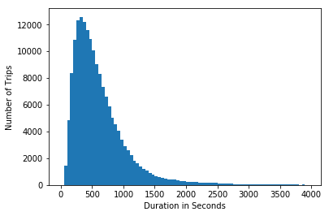

```python
# Duration of the bike rides in SECONDS

bins = np.arange(0, 4000, 50)
plt.hist(data = df, x = 'duration_sec', bins = bins);
plt.xlabel('Duration in Seconds')
plt.ylabel('Number of Trips');
```

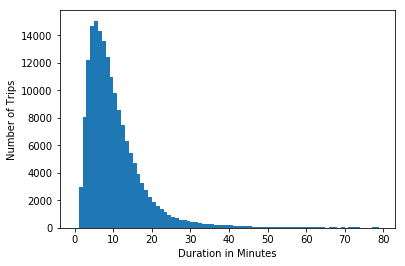

```python
# Duration of the bike rides in MINUTES

bins = np.arange(0, 80, 1)
plt.hist(data = df, x = 'duration_min', bins = bins);
plt.xlabel('Duration in Minutes')
plt.ylabel('Number of Trips');
```

### What is the top stations?

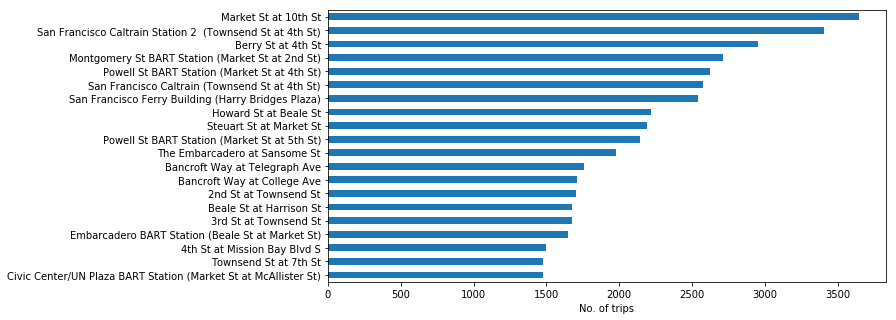

```python
# Top start station

plt.figure(figsize=[10, 5])
top_start_station = df.start_station_name.value_counts()
top_start_station[:20].plot(kind='barh', color=base_color)
plt.gca().invert_yaxis()
plt.xlabel('No. of trips');
```

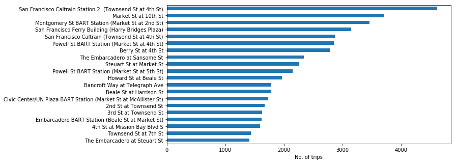

```python
# Top End station

plt.figure(figsize=[10, 5])
top_end_station = df.end_station_name.value_counts()
top_end_station[:20].plot(kind='barh', color=base_color)
plt.gca().invert_yaxis()
plt.xlabel('No. of trips');
```

Some stations are used frequntly more than others in the trip start or end.

### What is the age of the users for each trip?

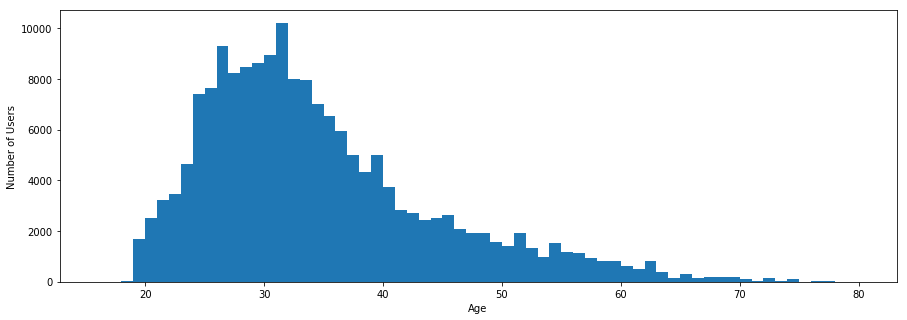

```python
# Age distribution

plt.figure(figsize=[15, 5])
#bins = np.arange(0, df['user_age'].max()+1, 1)
bins = np.arange(16, 80+1, 1)
plt.hist(data = df.dropna(), x = 'user_age', bins = bins)

plt.xlabel('Age')
plt.ylabel('Number of Users')
plt.show()
```

Most users' ages are between 20 to 40 years old.

### What is the type of user portion?

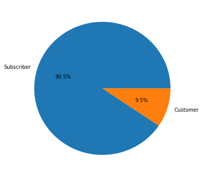

```python
# types of users

def pie(var):
    plt.figure(figsize=[6,6])
    sorted_counts = df[var].value_counts()
    plt.pie(sorted_counts, labels = sorted_counts.index, autopct='%1.1f%%');

pie('user_type') ;
```

Majority of users are subscribers.

### What is the gender of users portion?

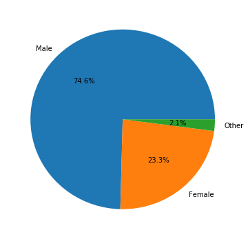

```python
# genders

pie('member_gender') ;
```

Male users are far more than females.

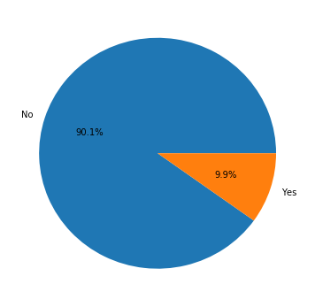

```python
# bike_share_for_all_trip

pie('bike_share_for_all_trip') ;
```

Majority is not using bike share for all trips.

### How many trips in a weekday?

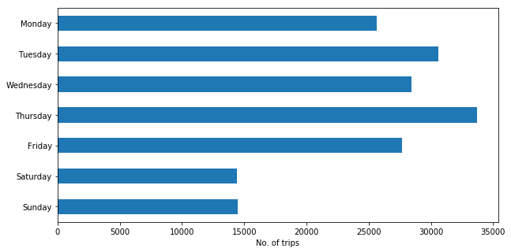

```python
# weekdays

weekday = ['Monday', 'Tuesday', 'Wednesday', 'Thursday', 'Friday', 'Saturday', 'Sunday']
plt.figure(figsize=[10, 5])
days = df.start_time_weekday.value_counts().reindex(weekday)
days.plot(kind='barh', color=base_color)
plt.gca().invert_yaxis()
plt.xlabel('No. of trips');
```

No great variations in total daily trips count over week days except weekends.

### How may trips strats in different hours?

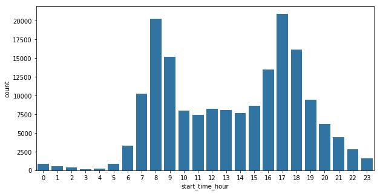

```python
# trip start hours
def bar_hour(xvar):
    hours_order = ['0', '1', '2', '3', '4', '5', '6', '7', '8', '9', '10', '11',
                   '12' , '13', '14' , '15', '16', '17', '18', '19', '20', '21', '22', '23']
    plt.figure(figsize=[10,5])
    sb.countplot(data=df, x=xvar, color=base_color, order=hours_order);

bar_hour('start_time_hour') ;
```

Morning and Afternoon Hours are higher than other hours

### How may trips ends in different hours?

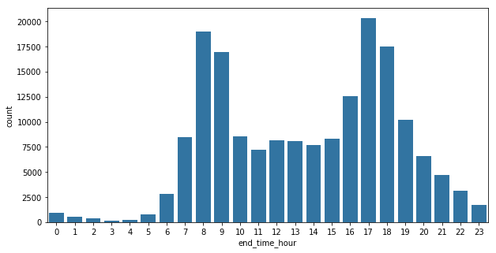

```python
# trip end hours

bar_hour('end_time_hour') ;
```

The same like start hours.

## Bivariate Exploration

### What is the user age and his duration for trips?

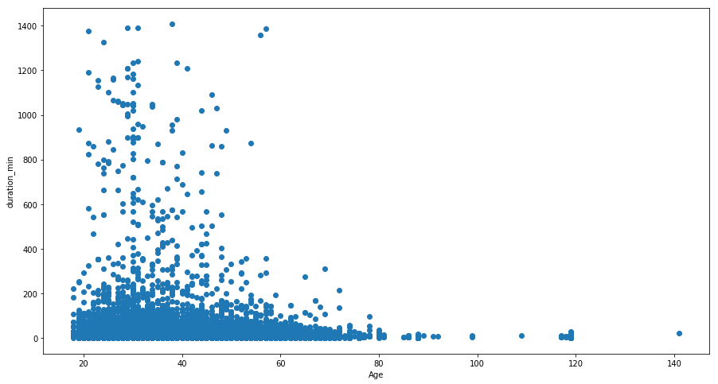

```python
# Age & duration

plt.figure(figsize=[15, 8])
plt.scatter(data = df, x = 'user_age', y = 'duration_min');
plt.xlabel('Age')
plt.ylabel('duration_min');
```

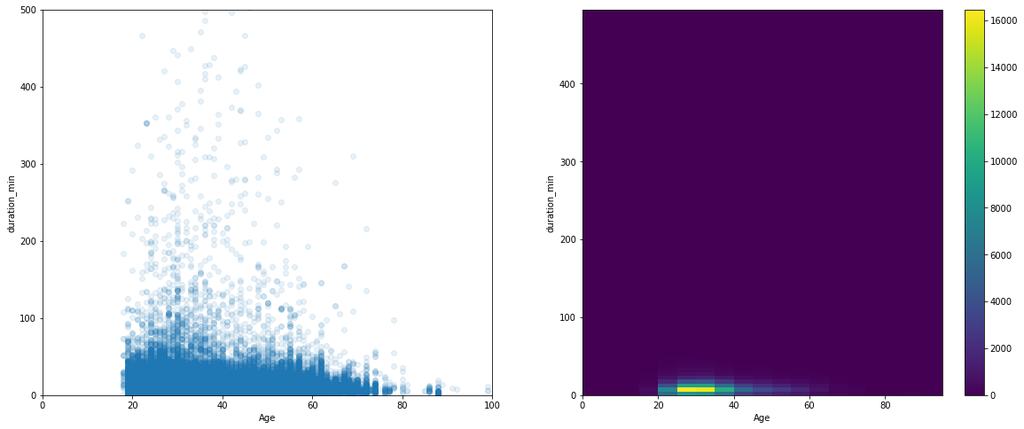

```python
# Age & duration

plt.figure(figsize=[20, 8])
# PLOT ON LEFT
plt.subplot(1, 2, 1)
sb.regplot(data = df, x = 'user_age', y = 'duration_min', scatter_kws={'alpha':1/10}, fit_reg = False)
plt.axis([0, 100, 0, 500])
plt.xlabel('Age')
plt.ylabel('duration_min');

# PLOT ON RIGHT
plt.subplot(1, 2, 2)
bins_x = np.arange(0, 100, 5)
bins_y = np.arange(0, 500, 5)
plt.hist2d(data = df, x = 'user_age', y = 'duration_min', bins = [bins_x, bins_y])
plt.colorbar()
plt.xlabel('Age')
plt.ylabel('duration_min');
```

Most frequent users aged between 20 and 40 with higher durations.

### What is distribution of users gender with trips duration?

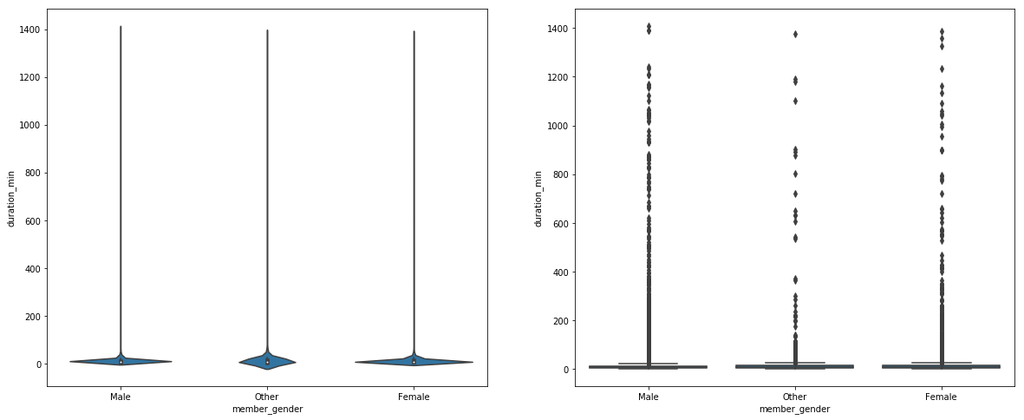

```python
# gender & duration

plt.figure(figsize=[20, 8])
# LEFT plot: violin plot
plt.subplot(1, 2, 1)
sb.violinplot(data=df, x='member_gender', y='duration_min', color=base_color);

# RIGHT plot: box plot
plt.subplot(1, 2, 2)
sb.boxplot(data=df, x='member_gender', y='duration_min', color=base_color);
```

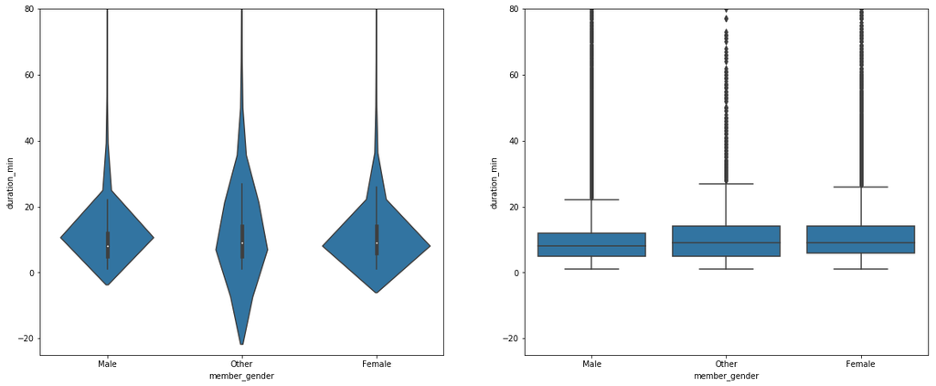

```python
# gender & duration

plt.figure(figsize=[20, 8])
# LEFT plot: violin plot
plt.subplot(1, 2, 1)
sb.violinplot(data=df, x='member_gender', y='duration_min', color=base_color)
plt.ylim([-25, 80]);

# RIGHT plot: box plot
plt.subplot(1, 2, 2)
sb.boxplot(data=df, x='member_gender', y='duration_min', color=base_color)
plt.ylim([-25, 80]);
```

Higher percentage of female and other rides longer trips than males although number of male riders is higher than others and females.

### What is distribution of users type with trips duration?

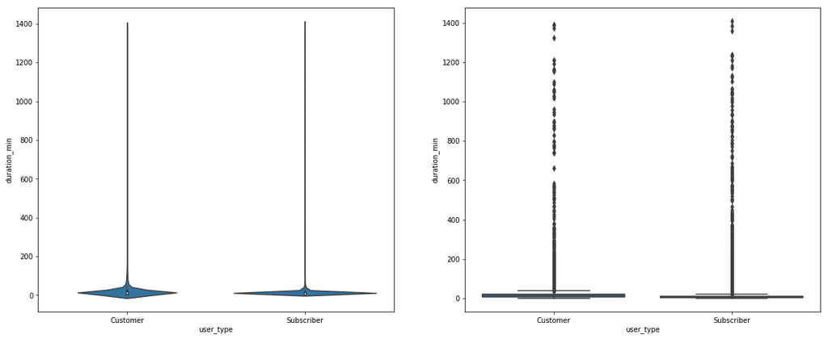

```python
# Type & duration

plt.figure(figsize=[20, 8])
# LEFT plot: violin plot
plt.subplot(1, 2, 1)
sb.violinplot(data=df, x='user_type', y='duration_min', color=base_color);

# RIGHT plot: box plot
plt.subplot(1, 2, 2)
sb.boxplot(data=df, x='user_type', y='duration_min', color=base_color);
```

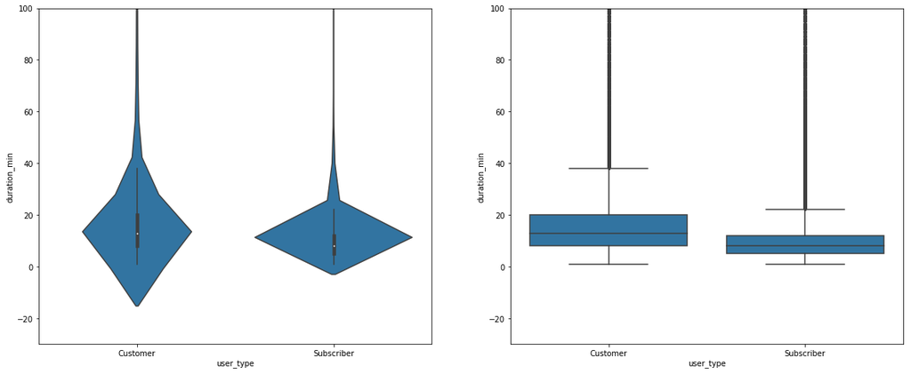

```python
## Type & duration

plt.figure(figsize=[20, 8])
# LEFT plot: violin plot
plt.subplot(1, 2, 1)
sb.violinplot(data=df, x='user_type', y='duration_min', color=base_color)
plt.ylim([-30, 100]);

# RIGHT plot: box plot
plt.subplot(1, 2, 2)
sb.boxplot(data=df, x='user_type', y='duration_min', color=base_color)
plt.ylim([-30, 100]);
```

Higher percentage of customer rides longer trips than subscriber although number of subscriber riders is higher than customer.

### What is distribution of users gender and type?

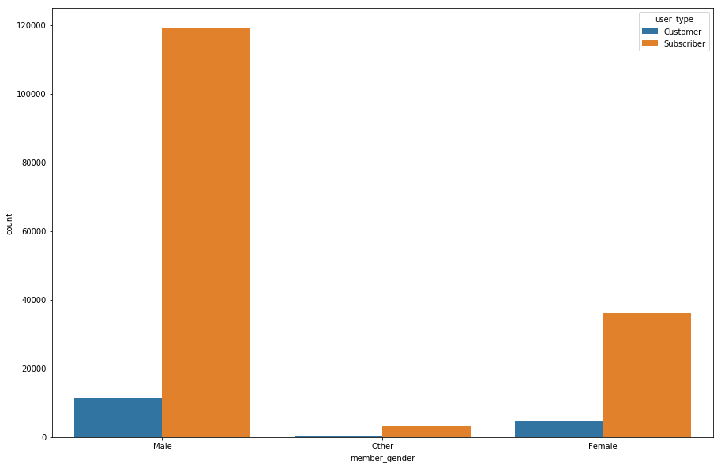

```python
# gender & type

plt.figure(figsize=[15, 10])
sb.countplot(data = df, x = 'member_gender', hue = 'user_type');
```

Males and subscribers are with more trips than females and customers.

### Talk about some of the relationships you observed in this part of the investigation. How did the feature(s) of interest vary with other features in the dataset?

> Trip Duration dependends on the age of the member, when the age between 20 to 45, the trip duration is higher than the older ages. Trip counts for some station for start station is higher and for some stations for end station is higher.

### Did you observe any interesting relationships between the other features (not the main feature(s) of interest)?

> For gender, male members is very high but it got lower trip duration. For user type, subscriber members is very high but it got lower trip duration than customer.

## Multivariate Exploration

### What is the relation between duration & gender & age?

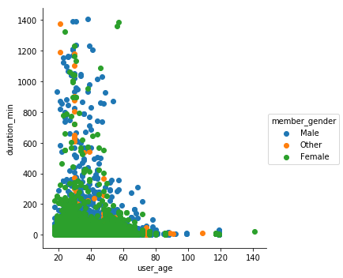

```python
# duration & gender & age

plt.figure(figsize = [20, 8]);
g = sb.FacetGrid(data = df, hue = 'member_gender', size = 5);
g.map(plt.scatter, 'user_age', 'duration_min');
g.add_legend();
```

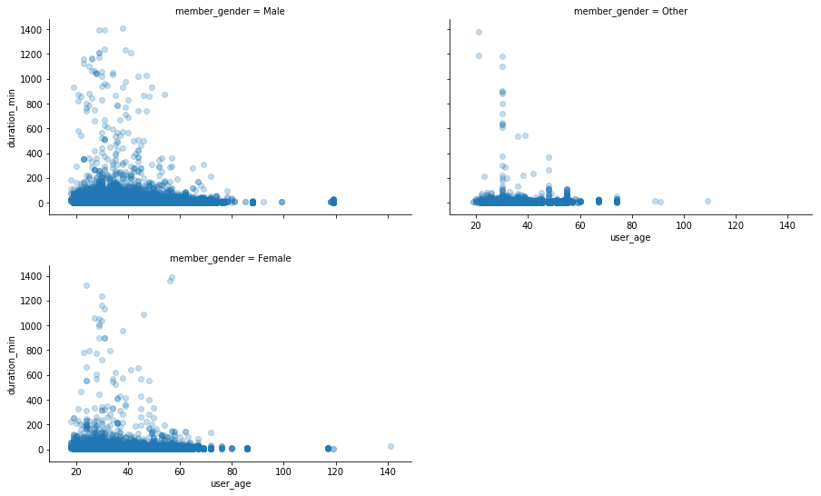

```python
g = sb.FacetGrid(data = df, col= 'member_gender' ,col_wrap = 2);
g.map (plt.scatter,'user_age','duration_min' ,alpha=0.25);
g.fig.set_size_inches(14, 8);
```

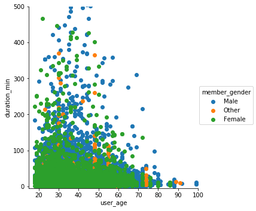

```python
# duration & gender & age

plt.figure(figsize = [20, 8]);
g = sb.FacetGrid(data = df, hue = 'member_gender', size = 5);
g.map(plt.scatter, 'user_age', 'duration_min');
g.add_legend();
plt.axis([15, 100, -5, 500 ]);
```

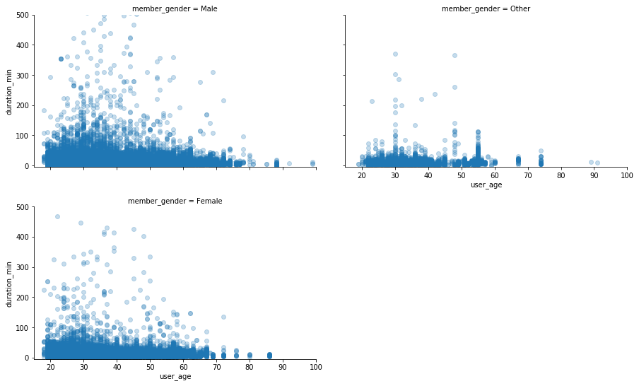

```python
g = sb.FacetGrid(data = df, col= 'member_gender' ,col_wrap = 2);
g.map (plt.scatter,'user_age','duration_min' ,alpha=0.25);
g.fig.set_size_inches(14, 8);
plt.axis([15, 100, -5, 500 ]);
```

For the age, duration, and gender, for the others leap at an older age (around 60 years) to got 50 trip duration.

### What is the relation between duration & type & age?

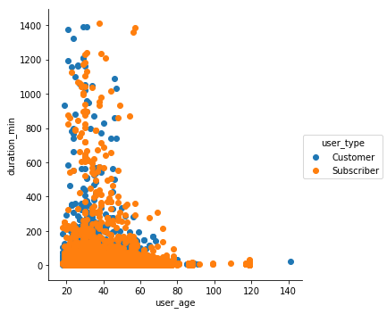

```python
# duration & type & age

plt.figure(figsize = [20, 8]);
g = sb.FacetGrid(data = df, hue = 'user_type', size = 5);
g.map(plt.scatter, 'user_age', 'duration_min');
g.add_legend();
```

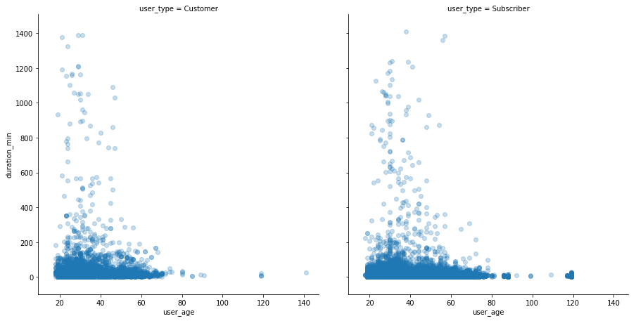

```python
g = sb.FacetGrid(data = df, col= 'user_type' ,col_wrap = 2);
g.map (plt.scatter,'user_age','duration_min' ,alpha=0.25);
g.fig.set_size_inches(14, 8);
```

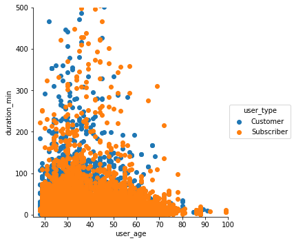

```python
# duration & type & age

plt.figure(figsize = [20, 8]);
g = sb.FacetGrid(data = df, hue = 'user_type', size = 5);
g.map(plt.scatter, 'user_age', 'duration_min');
g.add_legend();
plt.axis([15, 100, -5, 500 ]);
```

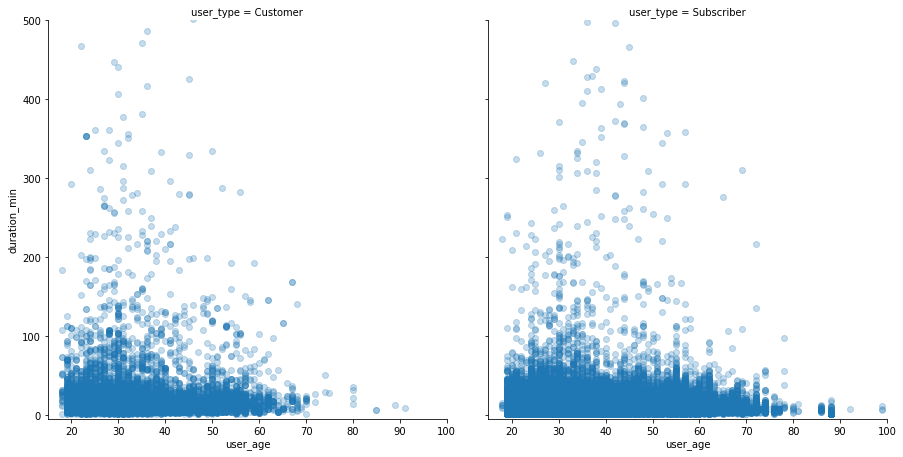

```python
g = sb.FacetGrid(data = df, col= 'user_type' ,col_wrap = 2);
g.map (plt.scatter,'user_age','duration_min' ,alpha=0.25);
g.fig.set_size_inches(14, 8);
plt.axis([15, 100, -5, 500 ]);
```

For the age, duration, and user type, both Customer and Subscriber are showing similar trends for age and trip duration, but for subscribers the trip duration is higher for older age.

### Talk about some of the relationships you observed in this part of the investigation. Were there features that strengthened each other in terms of looking at your feature(s) of interest?

> percentage is higher for women and other in trip duration although the number of users for male is higher. And,for the others leap at an older age (around 60 years) to got 50 trip duration which is a peak. Also, for subscribers the trip duration is higher than customer for older age.

### Were there any interesting or surprising interactions between features?

> leaping for other gender at an older. And, for subscribers the trip duration is higher than customer for older age